# Factor predicting school performance in California schools

STAT 420, Summer 2018, Group 13: bching3, cindyst2, rjs8, trapido2

07/30/2018

## Introduction

As part of California’s accountability program, the state Deptarment of Education measures student academic performance and its growth. To achieve this goal, from 1999-2013, the California Department of Education annually calculated the Academic Performance Index (API) for all public schools. These data sets are publicly available at the California Department of Education web site, https://www.cde.ca.gov/ta/ac/ap/apidatafiles.asp.

In addition to API scores, the dataset contains the school’s name, district, type (charter or not), student demographics, subject end of year test score averages, ranking in the state, class sizes, average parental education levels, and teacher credentials.

Our interest in this dataset is driven by the current administration’s Education Secretary’s push to increase the number of charter schools. With the test scores as the response, we hope to model how charter schools will perform compared to public schools using the other fields as predictors.

## Methods

```r
set.seed(42)
data_2010 = read.dbf("data/api10gdb.dbf", as.is = TRUE)
data_2007 = read.dbf("data/api07gdb.dbf", as.is = TRUE)
str(data_2010, attr = FALSE)
```

```
## 'data.frame':    10885 obs. of  178 variables:
##  $ CDS      : chr  "00000000000000" "01100170000000" "01100170109835" "01100170112607" ...
##  $ RTYPE    : chr  "X" "D" "S" "S" ...
##  $ STYPE    : chr  NA "1" "E" "H" ...
##  $ SPED     : chr  NA NA NA NA ...
##  $ SIZE     : chr  NA "S" NA NA ...
##  $ CHARTER  : chr  NA NA "D" "D" ...
##  $ SNAME    : chr  NA NA "FAME Public Charter" "Envision Academy for Arts & Technology" ...
##  $ DNAME    : chr  NA "Alameda County Office of Educa" "Alameda County Office of Educa" "Alameda County Office of Educa" ...
##  $ CNAME    : chr  NA "Alameda" "Alameda" "Alameda" ...
##  $ FLAG     : chr  NA NA NA NA ...
##  $ VALID    : chr  "4687905" "44" "987" "182" ...
##  $ API10    : chr  "767" "581" "761" "604" ...
##  $ API09    : chr  "754" "473" "743" "603" ...
##  $ TARGET   : chr  NA "D" "5" "10" ...
```

[output cut: 87 more lines]

We start out by looking at the data and removing any rows that have missing data since we would be unable to provide estimates for their values.

We also remove columns that are redundant. For instance the data set represented test scores with different variations such as African American API test scores (AA_API*), however in this study we are only focusing on the final, average API test scores.

We define some helper functions to aid up with data cleaning and model analysis

```r
#
# Utility functions to manipulate the data.
#

# Function to remove exact column names
remove_columns = function(dframe, columns_to_remove) {
  subset(dframe, select = !(colnames(dframe) %in% columns_to_remove))
}

# Function to remove matching column names
remove_columns_like = function(dframe, columns_to_remove) {
  tmp_df = data.frame(dframe)
  for(match in columns_to_remove) {
    tmp_df = subset(tmp_df, select = -grep(match, colnames(tmp_df), perl=TRUE, value=FALSE))
  }
  tmp_df
}

# threshold is a number from 0 to 1 to indicate how much NA you want to see
# threshold = 0.7 means show columns with 70% NAs
show_columns_with_na = function(dframe, threshold = 0.5) {
  cn = colnames(dframe)
  col_na_ratios = rep(0, length(cn))
  for(c in 1:length(cn)) {
    col_na_ratios[c] = mean(is.na(dframe[,cn[c]]))
  }
  print(cn[col_na_ratios > threshold])
  cn[col_na_ratios > threshold]
}

# Remove columns that are commonly unwanted in dataset
remove_common_columns = function(dframe) {

  # Remove all _TARG, _MET, _SIG, columns which are just metadata about whether targets were met
  # or whether columns were significant.
  dframe = remove_columns_like(dframe, c("_TARG", "_MET", "_SIG", "_NUM", "_GROW"))

  # Remove rows with YR_RND = Yes because they have mostly NA columns
  dframe = subset(dframe, subset = dframe$YR_RND != 'Yes', select =!(colnames(dframe) %in% c('YR_RND')))

  # Remove the names because we have the school id in the first column
  dframe = remove_columns(dframe, c("SNAME", "DNAME", "CNAME"))

  # Remove rows with AVG_ED = NA because there's not that much of them (37)
  dframe = subset(dframe, subset = !is.na(dframe$AVG_ED))

  # Remove ACS_K3, ACS_46, ACS_CORE, FULL, EMER because it's mostly if not all is NA
  dframe = remove_columns(dframe, c("ACS_K3", "ACS_46", "ACS_CORE", "FULL", "EMER"))
  # Remove all fields with component test scores because this is what we're trying to find relationships for.
  dframe = remove_columns_like(dframe, c("VCST_", "PCST_", "VCHS_", "PCHS", "CW_", "CWM2_", "CWS2_", "VCSTM2_", "PCSTM2_", "CWS_", "VCSTS2_", "PCSTS2_", "TOT_"))

  dframe = remove_columns_like(dframe, c("GRAD", "HSG", "SOME_COL"))


  dframe
}

# convert all columns listed in fac_pred to factors
conv_factor = function(dframe, columns_to_factor) {
  for(col in columns_to_factor) {
    if(col %in% colnames(dframe[0,])) {
      dframe[, col] = as.factor(dframe[, col])
    }
  }
  dframe
}

# convert all columns to numeric
conv_numeric = function(dframe, columns_to_numeric) {
  for(col in columns_to_numeric) {
    if(col %in% colnames(dframe[0,])) {
      dframe[, col] = as.numeric(dframe[, col])
    }
  }
  dframe
}

# Function to calculate loocv_rmse
calc_loocv_rmse = function(model) {
  sqrt(mean((resid(model) / (1 - hatvalues(model))) ^ 2))
}

# Function to plot qqplot and perform Shapiro and bptest
diagnostics = function(model, pcol = "grey", lcol = "dodgerblue", alpha = 0.05,
                       plotit = TRUE, testit = TRUE) {

  if (plotit == TRUE) {

    # side-by-side plots (one row, two columns)
    par(mfrow = c(1, 2))

    # fitted versus residuals
    plot(fitted(model), resid(model),
         col = pcol, pch = 20, cex = 1.5,
         xlab = "Fitted", ylab = "Residuals",
         main = "Fitted versus Residuals")
    abline(h = 0, col = lcol, lwd = 2)
    grid()

    # qq-plot
    qqnorm(resid(model), col = pcol, pch = 20, cex = 1.5)
    qqline(resid(model), col = lcol, lwd = 2)
    grid()
  }

  if (testit == TRUE) {
    # p-value and decision
    shapiro_pval = shapiro.test(resid(model))$p.value
    bptest_pval = bptest((model))$p.value
    list(shapiro_pval = shapiro_pval, bptest_pval = bptest_pval)
  }

}
```

We define some columns so we can easily convert them to either factor or numeric

```r
###################
# Common Columns
###################

# Define some common columns
# Factor Columns
fact_columns = c("RTYPE", "STYPE", "SPED", "SIZE", "CHARTER", "YR_RND",
                 "SCH_WIDE" , "COMP_IMP ", "BOTH", "AWARDS")

# Numeric Columns
num_columns = c("API09","API10", "API13", "API07", "API04",
             "MEDIAN13","MEDIAN12","MEDIAN10","MEDIAN09","MEDIAN07","MEDIAN06","MEDIAN04","MEDIAN03",
             "ST_RANK", "SIM_RANK", "sim_rank","st_rank", "SCI",
             "CDS", "VALID",
             "AA_API", "AI_API", "AS_API", "FI_API", "HI_API", "PI_API", "WH_API", "MR_API",
             "SD_API", "EL_API", "DI_API",
             "PCT_AA", "PCT_AI", "PCT_AS", "PCT_FI", "PCT_HI","PCT_PI", "PCT_WH", "PCT_MR",
             "MEALS", "P_GATE",  "P_MIGED", "P_EL", "P_RFEP", "P_DI",
             "CBMOB", "DMOB", "SMOB",
             "ACS_K3", "ACS_46", "ACS_CORE",
             "PCT_RESP", "NOT_HSG", "HSG", "SOME_COL", "COL_GRAD", "GRAD_SCH", "AVG_ED",
             "PEN_2", "PEN_35", "PEN_6", "PEN_78", "PEN_911","PEN_91",
             "ENROLL", "TESTED",
             "VCST_E28","PCST_E28","VCST_E91","PCST_E91","CW_CSTE",
             "VCST_M28","PCST_M28","VCST_M91","PCST_M91","CW_CSTM",
             "VCST_S28","PCST_S28","VCST_S91","PCST_S91","CWS_91",
             "VCST_H28","PCST_H28","VCST_H91","PCST_H91","CW_CSTH",
             "VCSTM2_91","PCSTM2_91","CWM2_91","CWS2_91","VCSTS2_91","PCSTS2_91",
             "VCST_LS10","PCST_LS10","CWM2_28","VCSTM2_28","PCSTM2_28",
              "VCHS_E","PCHS_E","CW_CHSE",
             "VCHS_M","PCHS_M","CW_CHSM",
              "TOT_28","TOT_91","CW_SCI",
             "CAPA",
             "PAR_OPT", "PARENT_OPT",
             "GROWTH","TARGET"
             )
```

```r
#############################
# Data Cleaning for 2007
#############################
# remove commonly removable columns
data_2007 = remove_common_columns(data_2007)

# assign none charter schools as NC
data_2007$CHARTER = ifelse(is.na(data_2007$CHARTER), "NC", data_2007$CHARTER)

# Remove columns unique to the dataset
# _api is related to API which we are trying to measure
data_2007 = remove_columns_like(data_2007, c("_API07", "_API06"))

# Remove schools designated as small for GROWTH and BASE purposes. It uses NA to mean not-small.
data_2007 = subset(data_2007, subset = is.na(data_2007$sm07) & is.na(data_2007$sm06), select = !(colnames(data_2007) %in% c('sm07','sm06')))

# Remove rows with MEDIAN13 or MEDIAN12 = NA
data_2007 = subset(data_2007, subset = !is.na(data_2007$MEDIAN07) | !is.na(data_2007$MEDIAN06))

# Remove all fields with component test scores because this is what we're trying to find relationships for.
data_2007 = remove_columns(data_2007, c("API07", "TARGET", "GROWTH", "COMP_IMP", "MEDIAN07", "MEDIAN06"))

# Iterate with any columns that have NAs: either transform the NA to something else,
# or remove the column, or remove the row.
# Remove columns if they don't look like they're needed according to this dataset's record layout
# (https://www.cde.ca.gov/ta/ac/ap/reclayout13g.asp)
other_cols = show_columns_with_na(data_2007)
```

```
## [1] "SPED"     "SIZE"     "FLAG"     "chg_data" "IRG5"
```

```r
data_2007 = remove_columns(data_2007, other_cols)
data_2007 = na.omit(data_2007)

unique(data_2007$RTYPE) # yields only one factor in dataset, so remove the column
```

```
## [1] "S"
```

```r
data_2007 = remove_columns(data_2007, c("RTYPE"))

# convert columns to factor
data_2007 = conv_factor(data_2007, fact_columns)

# convert columns to numeric
data_2007 = conv_numeric(data_2007, num_columns)
nrow(data_2007)
```

```
## [1] 6897
```

```r
ncol(data_2007)
```

```
## [1] 40
```

```r
#############################
# Data Cleaning for 2010
#############################
# remove commonly removable columns
data_2010 = remove_common_columns(data_2010)

# assign NC to none charter schools
data_2010$CHARTER = ifelse(is.na(data_2010$CHARTER), "NC", data_2010$CHARTER)

# Remove columns unique to the dataset
# _api is related to API which we are trying to measure
data_2010 = remove_columns_like(data_2010, c("_api10", "_API09"))

# Remove schools designated as small for GROWTH and BASE purposes. It uses NA to mean not-small.
data_2010 = subset(data_2010, subset = is.na(data_2010$sm10) & is.na(data_2010$sm09), select = !(colnames(data_2010) %in% c('sm10','sm09')))

# Remove rows with MEDIAN13 or MEDIAN12 = NA
data_2010 = subset(data_2010, subset = !is.na(data_2010$MEDIAN10) | !is.na(data_2010$MEDIAN09))

# Remove all fields with component test scores because this is what we're trying to find relationships for.
data_2010 = remove_columns(data_2010, c("API09", "TARGET", "GROWTH", "COMP_IMP", "MEDIAN10", "MEDIAN09", "SCH_WIDE"))

# Remove columns with too many NA
other_cols = show_columns_with_na(data_2010)
```

```
## [1] "SPED"     "SIZE"     "FLAG"     "chg_data" "IRG5"
```

```r
data_2010 = remove_columns(data_2010, other_cols)
data_2010 = na.omit(data_2010)

unique(data_2010$RTYPE) # yields only one factor in dataset, so remove the column
```

```
## [1] "S"
```

```r
data_2010 = remove_columns(data_2010, c("RTYPE"))

# convert columns to factor
data_2010 = conv_factor(data_2010, fact_columns)

# convert columns to numeric
data_2010 = conv_numeric(data_2010, num_columns)

nrow(data_2010)
```

```
## [1] 7378
```

We have decided to draw 700 random samples from the entire data set because smaller samples are easier to explain. We then split these samples in half, 350 for training and 350 for testing. With a population size of roughly 7000 valid observations, the sample size of 350 gives us about 95% confidence with 5% of error of accurately representing the model.

```r
grp_num = 13
set.seed(grp_num)
sample_size = 700

# 2007
# Split the dataset into training and test data set
# Randomly select 600 observations from 2010 data set
ridx = sample(nrow(data_2007), sample_size)
data_2007 = data_2007[ridx, ]

# split dataframe into training and test
(n = nrow(data_2007))
```

```
## [1] 700
```

```r
trn_idx = sample(nrow(data_2007), n/2)
data_2007_trn = data_2007[trn_idx, ]
data_2007_tst = data_2007[-trn_idx, ]

# 2010
# Split the dataset into training and test data set
# Randomly select 600 observations from 2010 data set
ridx = sample(nrow(data_2010), sample_size)
data_2010 = data_2010[ridx, ]

# split dataframe into training and test
(n = nrow(data_2010))
```

```
## [1] 700
```

```r
trn_idx = sample(nrow(data_2010), n/2)
data_2010_trn = data_2010[trn_idx, ]
data_2010_tst = data_2010[-trn_idx, ]
```

We try to fit all the predictors and see if any of the predictors seems promising:

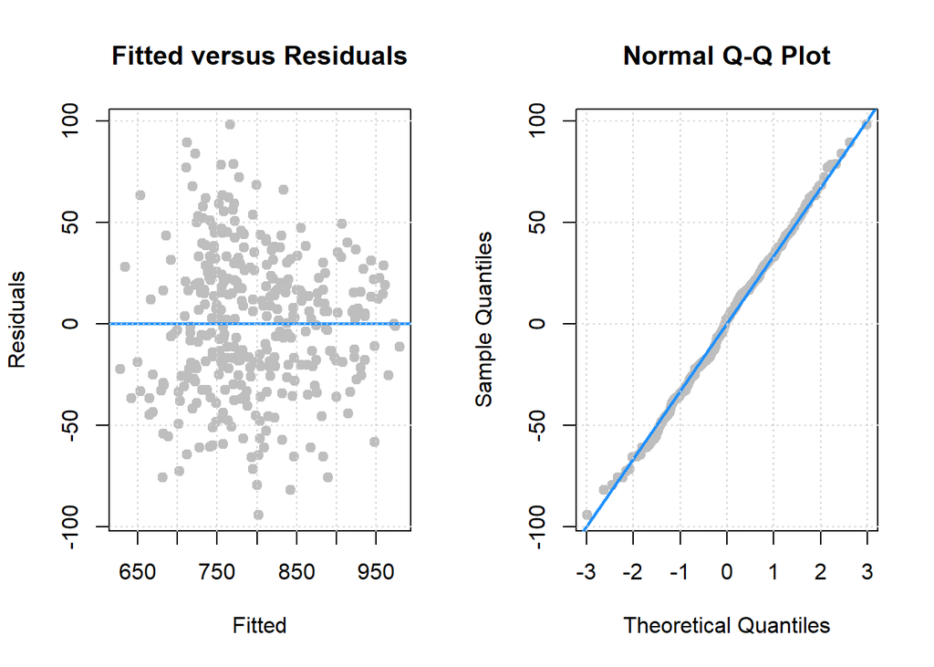

```
## $shapiro_pval
## [1] 0.7156423
##
## $bptest_pval
##          BP
## 0.001543026
```

```r
mod_big_2010 = lm(API10  ~ . , data = data_2010_trn )
n = nrow(data_2010_trn)
mod_aic_2010 = step(mod_big_2010, direction = "backward", k = log(n), trace = FALSE)

# check assumptions
diagnostics(mod_aic_2010)
```

```r
vif(mod_aic_2010)
```

```
##    VALID     BOTH   PCT_AS   PCT_WH    MEALS   P_GATE     P_DI   AVG_ED
## 2.211220 1.116887 1.720093 3.428478 7.004518 1.295887 1.140472 6.510086
##   PEN_78  PEN_911
## 1.270633 2.006877
```

```r
summary(mod_aic_2010)
```

```
##
## Call:
## lm(formula = API10 ~ VALID + BOTH + PCT_AS + PCT_WH + MEALS +
##     P_GATE + P_DI + AVG_ED + PEN_78 + PEN_911, data = data_2010_trn)
##
## Residuals:
##     Min      1Q  Median      3Q     Max
## -94.196 -22.282   2.108  22.751  98.080
##
## Coefficients:
##               Estimate Std. Error t value Pr(>|t|)
## (Intercept) 732.021147  25.105015  29.158  < 2e-16 ***
## VALID         0.017758   0.006364   2.790 0.005564 **
## BOTHYes      35.685921   4.003840   8.913  < 2e-16 ***
## PCT_AS        0.708203   0.182988   3.870 0.000130 ***
## PCT_WH        0.476472   0.138210   3.447 0.000637 ***
## MEALS        -0.709185   0.161387  -4.394 1.49e-05 ***
## P_GATE        1.337480   0.241472   5.539 6.12e-08 ***
## P_DI         -1.833774   0.471459  -3.890 0.000121 ***
## AVG_ED       30.651386   5.945848   5.155 4.32e-07 ***
## PEN_78       -0.717264   0.077260  -9.284  < 2e-16 ***
## PEN_911      -0.913949   0.077667 -11.768  < 2e-16 ***
## ---
## Signif. codes:  0 '***' 0.001 '**' 0.01 '*' 0.05 '.' 0.1 ' ' 1
##
## Residual standard error: 35.01 on 339 degrees of freedom
## Multiple R-squared:  0.8201, Adjusted R-squared:  0.8148
## F-statistic: 154.5 on 10 and 339 DF,  p-value: < 2.2e-16
```

Even though this model has some collinearity issues, it looks pretty promising! We see that ethnicity and parent’s education seem to be highly related to student’s API scores, we will focus on these predictors to fit our model.

```r
cor(subset(data_2010_trn,select=c('API10', 'PCT_AA', 'PCT_AI', 'PCT_AS', 'PCT_FI', 'PCT_HI', 'PCT_PI', 'PCT_WH', 'PCT_MR')))
```

```
##              API10      PCT_AA      PCT_AI      PCT_AS      PCT_FI
## API10   1.00000000 -0.22129641 -0.04131393  0.39018997  0.12850811
## PCT_AA -0.22129641  1.00000000 -0.10417815 -0.08822004  0.05522032
## PCT_AI -0.04131393 -0.10417815  1.00000000 -0.13016159 -0.09477388
## PCT_AS  0.39018997 -0.08822004 -0.13016159  1.00000000  0.27442935
## PCT_FI  0.12850811  0.05522032 -0.09477388  0.27442935  1.00000000
## PCT_HI -0.63866775 -0.13154629 -0.15688543 -0.41751771 -0.23746029
## PCT_PI -0.14779532  0.22355466  0.06581100  0.07009951  0.18483987
## PCT_WH  0.58046668 -0.27502909  0.26172648 -0.04246654 -0.07606463
## PCT_MR  0.26658333  0.03741073  0.05846450  0.09464713  0.05134223
##             PCT_HI      PCT_PI      PCT_WH      PCT_MR
## API10  -0.63866775 -0.14779532  0.58046668  0.26658333
## PCT_AA -0.13154629  0.22355466 -0.27502909  0.03741073
## PCT_AI -0.15688543  0.06581100  0.26172648  0.05846450
## PCT_AS -0.41751771  0.07009951 -0.04246654  0.09464713
## PCT_FI -0.23746029  0.18483987 -0.07606463  0.05134223
## PCT_HI  1.00000000 -0.08750612 -0.73776739 -0.43737867
## PCT_PI -0.08750612  1.00000000 -0.10340446  0.09853658
## PCT_WH -0.73776739 -0.10340446  1.00000000  0.31425042
## PCT_MR -0.43737867  0.09853658  0.31425042  1.00000000
```

Since the entire ethnicity adds up to 100%, the percentage of ethnic populations have a somewhat high collinearity.

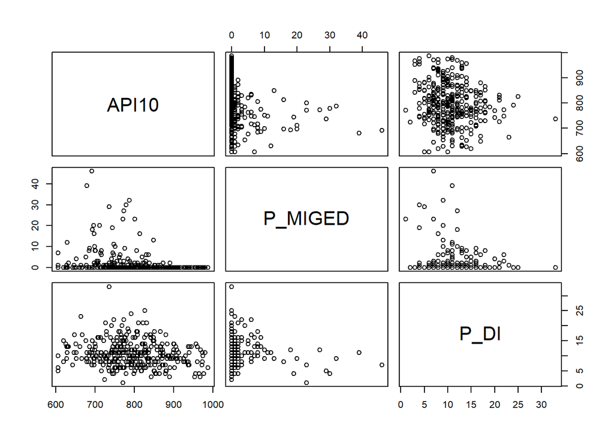

```r
pairs(subset(data_2010_trn,select=c('API10', 'P_MIGED', 'P_DI')))
```

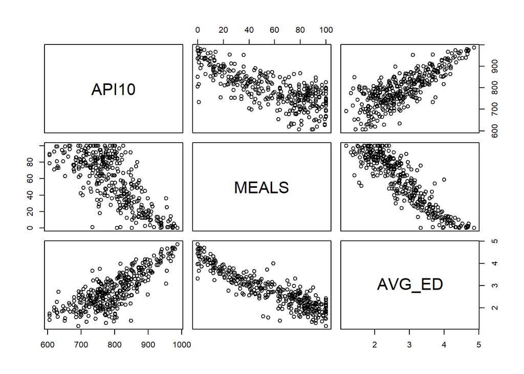

```r
pairs(subset(data_2010_trn,select=c('API10', 'MEALS', 'AVG_ED')))
```

`MEALS` corresponds to student’s eligibility for free or reduced price meal program. Perhaps it is not surprising to see that `MEALS` are highly correlated with the parent’s education level `AVG_ED`.

```r
#################
# 2010
#################

mod_2010 = lm(API10  ~  PEN_35 +  poly(PCT_AS, 2) +  poly(PCT_AA, 2)  + PCT_WH + poly(P_GATE, 2) + log(P_DI) + DMOB + PCT_RESP + poly(AVG_ED, 3):MEALS  , data = data_2010_trn )
```

## Results

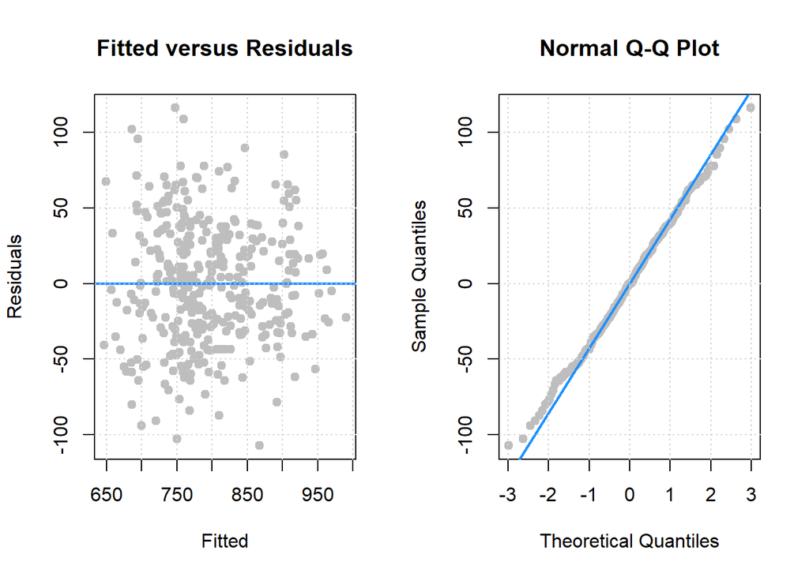

```
## $shapiro_pval
## [1] 0.7465454
##
## $bptest_pval
##         BP
## 0.01315091
```

```r
# check assumptions
diagnostics(mod_2010)
```

```r
# check how the model is fitting
summary(mod_2010)
```

```
##
## Call:
## lm(formula = API10 ~ PEN_35 + poly(PCT_AS, 2) + poly(PCT_AA,
##     2) + PCT_WH + poly(P_GATE, 2) + log(P_DI) + DMOB + PCT_RESP +
##     poly(AVG_ED, 3):MEALS, data = data_2010_trn)
##
## Residuals:
##      Min       1Q   Median       3Q      Max
## -107.150  -28.688   -0.009   28.996  116.239
##
## Coefficients:
##                         Estimate Std. Error t value Pr(>|t|)
## (Intercept)            791.62927   42.79995  18.496  < 2e-16 ***
## PEN_35                   0.97367    0.07394  13.167  < 2e-16 ***
## poly(PCT_AS, 2)1       318.69540   48.78427   6.533 2.40e-10 ***
## poly(PCT_AS, 2)2         3.75819   42.96083   0.087 0.930343
## poly(PCT_AA, 2)1       -60.39022   46.48807  -1.299 0.194821
## poly(PCT_AA, 2)2       191.56346   42.78525   4.477 1.04e-05 ***
## PCT_WH                   0.79768    0.14082   5.665 3.18e-08 ***
## poly(P_GATE, 2)1       237.75863   45.13317   5.268 2.47e-07 ***
## poly(P_GATE, 2)2        -0.51320   43.75331  -0.012 0.990648
## log(P_DI)              -18.89997    5.68713  -3.323 0.000988 ***
## DMOB                    -0.22169    0.40202  -0.551 0.581697
## PCT_RESP                 0.41365    0.13288   3.113 0.002013 **
## poly(AVG_ED, 3)1:MEALS  23.69932    2.45483   9.654  < 2e-16 ***
## poly(AVG_ED, 3)2:MEALS  16.34302    2.35871   6.929 2.18e-11 ***
## poly(AVG_ED, 3)3:MEALS   6.62361    1.39661   4.743 3.13e-06 ***
## ---
## Signif. codes:  0 '***' 0.001 '**' 0.01 '*' 0.05 '.' 0.1 ' ' 1
##
## Residual standard error: 40.97 on 335 degrees of freedom
## Multiple R-squared:  0.7565, Adjusted R-squared:  0.7464
## F-statistic: 74.36 on 14 and 335 DF,  p-value: < 2.2e-16
```

```r
vif(mod_2010)
```

```
##                           GVIF Df GVIF^(1/(2*Df))
## PEN_35                1.071859  1        1.035306
## poly(PCT_AS, 2)       1.557622  2        1.117160
## poly(PCT_AA, 2)       1.398136  2        1.087395
## PCT_WH                2.599116  1        1.612178
## poly(P_GATE, 2)       1.382351  2        1.084313
## log(P_DI)             1.229513  1        1.108834
## DMOB                  1.092718  1        1.045332
## PCT_RESP              1.095612  1        1.046715
## poly(AVG_ED, 3):MEALS 3.413798  3        1.227080
```

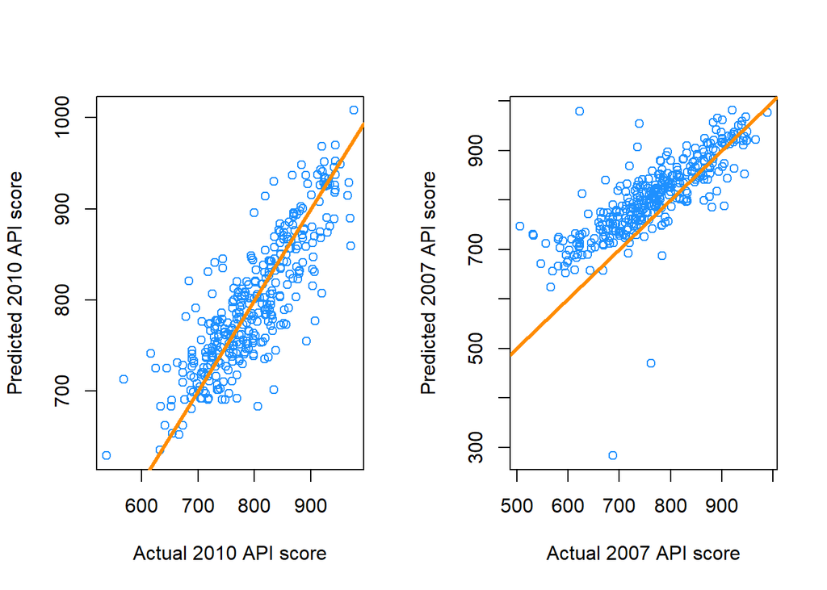

```r
par(mfrow = c(1, 2))
# see how well we predict on 2010 test set
pred_2010 = predict(mod_2010, newdata = data_2010_tst)
plot(pred_2010 ~ data_2010_tst$API10, col = "dodgerblue", xlab = "Actual 2010 API score", ylab = "Predicted 2010 API score")
abline(a = 0, b = 1, col = "darkorange", lwd = 3)

# see how well we predict on 2007 test set
pred_2007 = predict(mod_2010, newdata = data_2007_tst)
plot(pred_2007 ~ data_2007_tst$API06, col = "dodgerblue", xlab = "Actual 2007 API score", ylab = "Predicted 2007 API score")
abline(a = 0, b = 1, col = "darkorange", lwd = 3)
```

## Discussion

Looking at the `GVIF^(1/(2*Df))` column, we also see that none of the predictors have collinearity issues.

In this particular model, we see that the following predictors being significant with a significance level of 0.05:

- Parent’s average education (AVG_ED)
- Percentage of students that are eligible in the free or reduced price meal program (MEALS)
- Ethnicity (PCT_AS, PCT_AA, PCT_WH)
- Percentage of participants in gifted and talented education programs (P_GATE)
- Percentage of enrollment for 3~5 grades (PEN_35)
- Percent of Student Answer Documents with Parent Education Level Information(PCT_RESP)
- Percent of Students with Disabilities (P_DI)

We see that the percentage of students in gifted program (P_GATE) also has a positive relationship for the first order term (237.7586322) while P_DI has a slight negative correlation (-18.8999699).

We can probably hypothesize that parents with higher education learn how to teach the kids more, or, since parent education is highly tied to family income, that in higher income families parents have more time to spend with their children, hence ensuring the children’s success in school. Lastly, we see that there is also high correlation of student’s ethnicity. This may be due to the fact that Asian American families may have a higher income. We can see that there is negative correlation between Asian family and being economically disadvantaged.

```r
cor(data_2010_trn[, c("PCT_AS", "MEALS")])
```

```
##            PCT_AS      MEALS
## PCT_AS  1.0000000 -0.3353956
## MEALS  -0.3353956  1.0000000
```

Again this model is not the only model that will fit. Since ethnicity has a collinearity issue (since all percentages add up to 100%), the model will pick a particular ethnicity depending on the data set. So these predictors are not obsolete.

We see that this model also predicts the student’s test score somewhat well in the 2007 data set.

In conclusion, it seems that the main factors affecting the student’s test scores are the family’s background in education and income level. There doesn’t seem much of an impact from school here. We see that there are no effects on whether the school is a charter school or not. Perhaps instead of pushing for charter schools, the state department should focus on families with lower education or economically disadvantaged first. Finally, please note that these results simply are correlation and not causation.

## Appendix

Tools to help us calculate sample size needed: https://www.qualtrics.com/blog/calculating-sample-size/